# Sleep health and lifestyle

Ms. Orapit Pataraanant 6423765046

2023-12-16

## **Introduction**

Sleep is like a super recharge for your body and brain, It’s a natural state where your physical activity slows down and repair your body, refresh your brain during sleep to get ready for the next day.

This analysis will present on sleep disorder insight and recommendation from the dataset through data exploration, analysis and hypothesis testing.

### **1. Data Selection**

Source: kaggle https://www.kaggle.com/datasets/uom190346a/sleep-health-and-lifestyle-dataset

Size: 3 kB

Dataset information:

- Rows: 374
- Columns: 13
- Datatype: Character and Numeric

```r
library(tidyverse)
library(ggplot2)
library(skimr)
library(stringr)
library(knitr)
library(ggpubr)
library(patchwork)
library(descr)

df <- read_csv("Sleep_health_and_lifestyle_dataset.csv")

glimpse(df)
```

```
## Rows: 374
## Columns: 13
## $ `Person ID`               <dbl> 1, 2, 3, 4, 5, 6, 7, 8, 9, 10, 11, 12, 13, 1…
## $ Gender                    <chr> "Male", "Male", "Male", "Male", "Male", "Mal…
## $ Age                       <dbl> 27, 28, 28, 28, 28, 28, 29, 29, 29, 29, 29, …
## $ Occupation                <chr> "Software Engineer", "Doctor", "Doctor", "Sa…
## $ `Sleep Duration`          <dbl> 6.1, 6.2, 6.2, 5.9, 5.9, 5.9, 6.3, 7.8, 7.8,…
## $ `Quality of Sleep`        <dbl> 6, 6, 6, 4, 4, 4, 6, 7, 7, 7, 6, 7, 6, 6, 6,…
## $ `Physical Activity Level` <dbl> 42, 60, 60, 30, 30, 30, 40, 75, 75, 75, 30, …
## $ `Stress Level`            <dbl> 6, 8, 8, 8, 8, 8, 7, 6, 6, 6, 8, 6, 8, 8, 8,…
## $ `BMI Category`            <chr> "Overweight", "Normal", "Normal", "Obese", "…
## $ `Blood Pressure`          <chr> "126/83", "125/80", "125/80", "140/90", "140…
## $ `Heart Rate`              <dbl> 77, 75, 75, 85, 85, 85, 82, 70, 70, 70, 70, …
## $ `Daily Steps`             <dbl> 4200, 10000, 10000, 3000, 3000, 3000, 3500, …
## $ `Sleep Disorder`          <chr> "None", "None", "None", "Sleep Apnea", "Slee…
```

```r
skim(df)
```

Data summary

| Name | df |
| --- | --- |
| Number of rows | 374 |
| Number of columns | 13 |
| _______________________ |  |
| Column type frequency: |  |
| character | 5 |
| numeric | 8 |
| ________________________ |  |
| Group variables | None |

**Variable type: character**

| skim_variable | n_missing | complete_rate | min | max | empty | n_unique | whitespace |
| --- | --- | --- | --- | --- | --- | --- | --- |
| Gender | 0 | 1 | 4 | 6 | 0 | 2 | 0 |
| Occupation | 0 | 1 | 5 | 20 | 0 | 11 | 0 |
| BMI Category | 0 | 1 | 5 | 13 | 0 | 4 | 0 |
| Blood Pressure | 0 | 1 | 6 | 6 | 0 | 25 | 0 |
| Sleep Disorder | 0 | 1 | 4 | 11 | 0 | 3 | 0 |

**Variable type: numeric**

| skim_variable | n_missing | complete_rate | mean | sd | p0 | p25 | p50 | p75 | p100 | hist |
| --- | --- | --- | --- | --- | --- | --- | --- | --- | --- | --- |
| Person ID | 0 | 1 | 187.50 | 108.11 | 1.0 | 94.25 | 187.5 | 280.75 | 374.0 | ▇▇▇▇▇ |
| Age | 0 | 1 | 42.18 | 8.67 | 27.0 | 35.25 | 43.0 | 50.00 | 59.0 | ▆▆▇▃▅ |
| Sleep Duration | 0 | 1 | 7.13 | 0.80 | 5.8 | 6.40 | 7.2 | 7.80 | 8.5 | ▇▆▇▇▆ |
| Quality of Sleep | 0 | 1 | 7.31 | 1.20 | 4.0 | 6.00 | 7.0 | 8.00 | 9.0 | ▁▇▆▇▅ |
| Physical Activity Level | 0 | 1 | 59.17 | 20.83 | 30.0 | 45.00 | 60.0 | 75.00 | 90.0 | ▇▇▇▇▇ |
| Stress Level | 0 | 1 | 5.39 | 1.77 | 3.0 | 4.00 | 5.0 | 7.00 | 8.0 | ▇▃▂▃▃ |
| Heart Rate | 0 | 1 | 70.17 | 4.14 | 65.0 | 68.00 | 70.0 | 72.00 | 86.0 | ▇▇▂▁▁ |
| Daily Steps | 0 | 1 | 6816.84 | 1617.92 | 3000.0 | 5600.00 | 7000.0 | 8000.00 | 10000.0 | ▁▅▇▆▂ |

### **2. Data Preprocessing**

- No missing value and empty to be cleaned
- Separate blood pressure into 2 columns, systolic and diastolic
- Change “Normal Weight” to “Normal”

```r
# 2. Data Preprocessing

# Separate blood pressure columns > systolic , diastolic

df_prep <- df %>%
  mutate(bp_systolic = str_extract(`Blood Pressure`,"([1-9].+)/", group = TRUE),
         bp_diastolic = str_extract(`Blood Pressure`,"/([1-9].+)", group = TRUE)) %>%
  mutate(bp_systolic = as.numeric(bp_systolic),
         bp_diastolic = as.numeric(bp_diastolic)) %>%
  mutate(`BMI Category` = if_else(`BMI Category` == "Normal Weight","Normal",`BMI Category`)) %>%
  select(-`Blood Pressure`)
```

### **3. Exploratory Data Analysis**

##### 3.1 Summary Statistics of dataset

```
##    Person ID         Gender               Age         Occupation
##  Min.   :  1.00   Length:374         Min.   :27.00   Length:374
##  1st Qu.: 94.25   Class :character   1st Qu.:35.25   Class :character
##  Median :187.50   Mode  :character   Median :43.00   Mode  :character
##  Mean   :187.50                      Mean   :42.18
##  3rd Qu.:280.75                      3rd Qu.:50.00
##  Max.   :374.00                      Max.   :59.00
##  Sleep Duration  Quality of Sleep Physical Activity Level  Stress Level
##  Min.   :5.800   Min.   :4.000    Min.   :30.00           Min.   :3.000
##  1st Qu.:6.400   1st Qu.:6.000    1st Qu.:45.00           1st Qu.:4.000
##  Median :7.200   Median :7.000    Median :60.00           Median :5.000
##  Mean   :7.132   Mean   :7.313    Mean   :59.17           Mean   :5.385
##  3rd Qu.:7.800   3rd Qu.:8.000    3rd Qu.:75.00           3rd Qu.:7.000
##  Max.   :8.500   Max.   :9.000    Max.   :90.00           Max.   :8.000
##  BMI Category         Heart Rate     Daily Steps    Sleep Disorder
##  Length:374         Min.   :65.00   Min.   : 3000   Length:374
##  Class :character   1st Qu.:68.00   1st Qu.: 5600   Class :character
##  Mode  :character   Median :70.00   Median : 7000   Mode  :character
##                     Mean   :70.17   Mean   : 6817
##                     3rd Qu.:72.00   3rd Qu.: 8000
##                     Max.   :86.00   Max.   :10000
##   bp_systolic     bp_diastolic
##  Min.   :115.0   Min.   :75.00
##  1st Qu.:125.0   1st Qu.:80.00
##  Median :130.0   Median :85.00
##  Mean   :128.6   Mean   :84.65
##  3rd Qu.:135.0   3rd Qu.:90.00
##  Max.   :142.0   Max.   :95.00
```

##### 3.2 Overview of Quality of sleep, Stress level and Physical activity level separated by sleep disorder categories

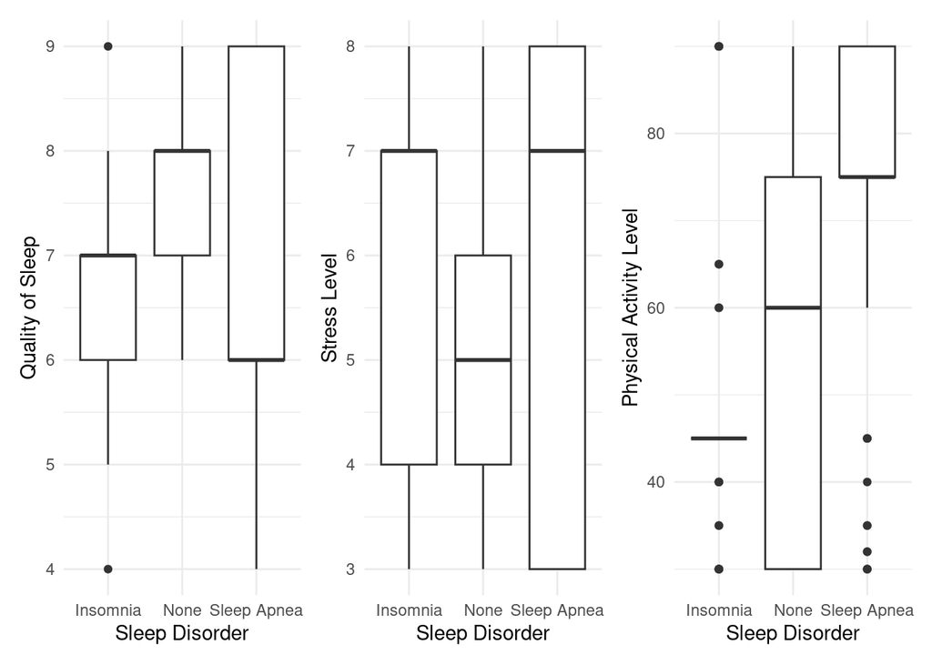

> Insomnia disorder peoples have sleep quality lower than non-sleep disorder peoples

##### 3.3 Relationship between Sleep quality and

- Sleep duration
- Physical activity
- Stress level

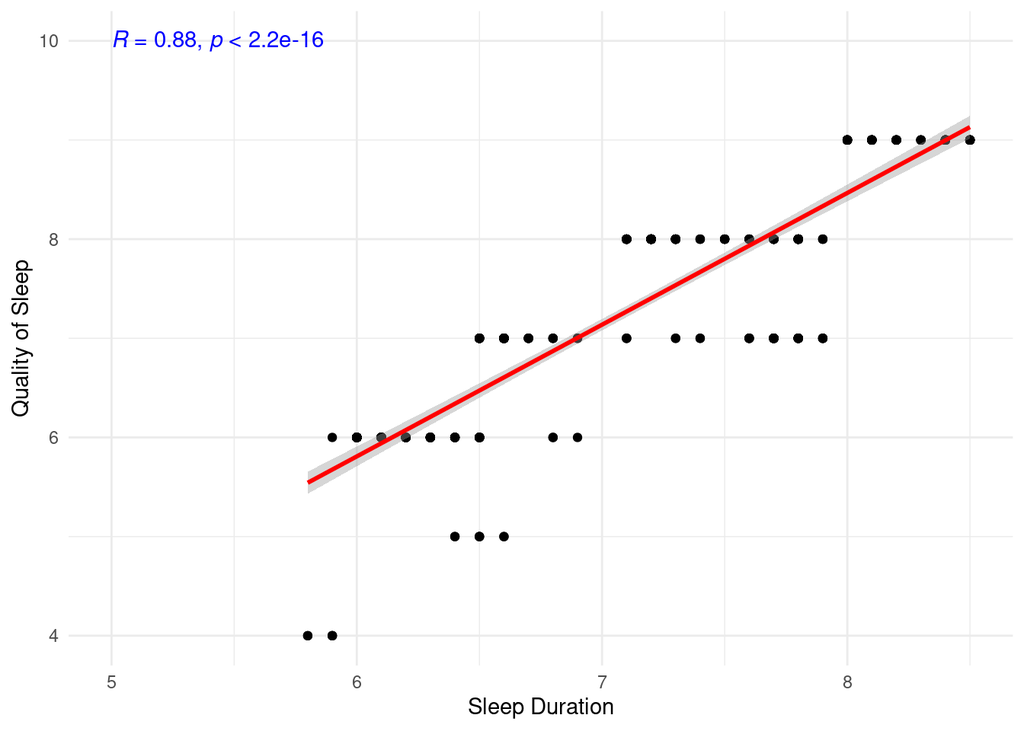

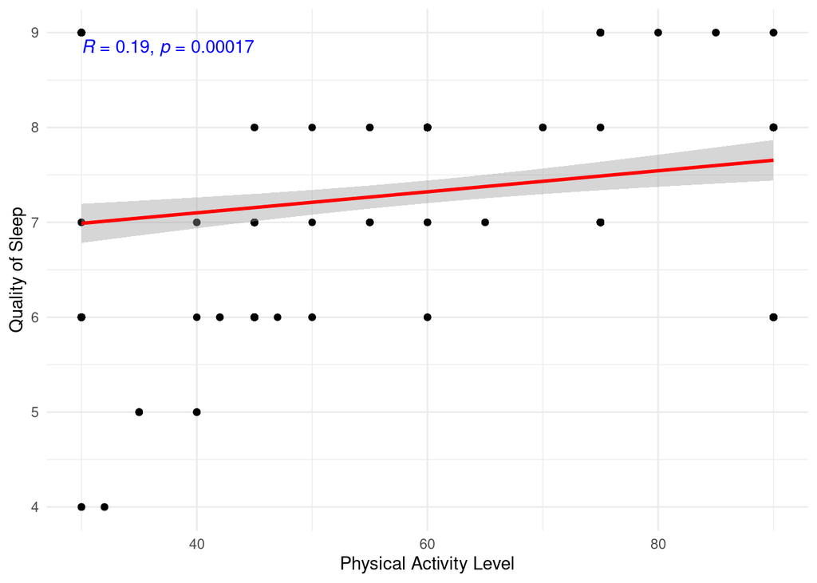

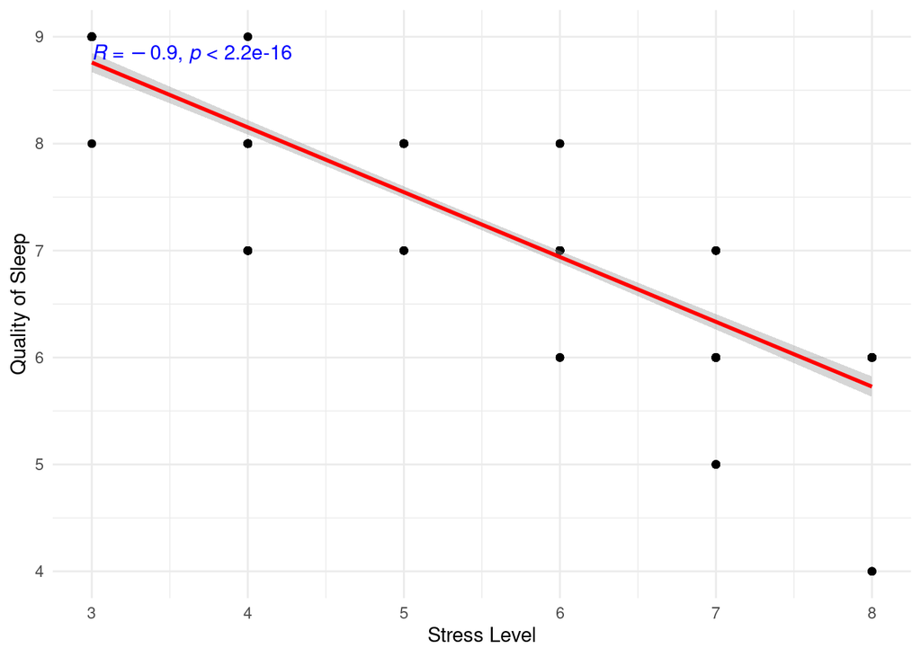

> Sleep duration is significantly relate to Sleep quality (p <= 0.05) and strong correlation with R = 0.88

> Physical activity level is significantly relate to Sleep quality (p <= 0.05) but weak correlation with R = 0.19

> Stress level is significantly relate to Sleep quality (p <= 0.05) and strong correlation with R = -0.9

##### 3.4 Sleep quality separate by BMI

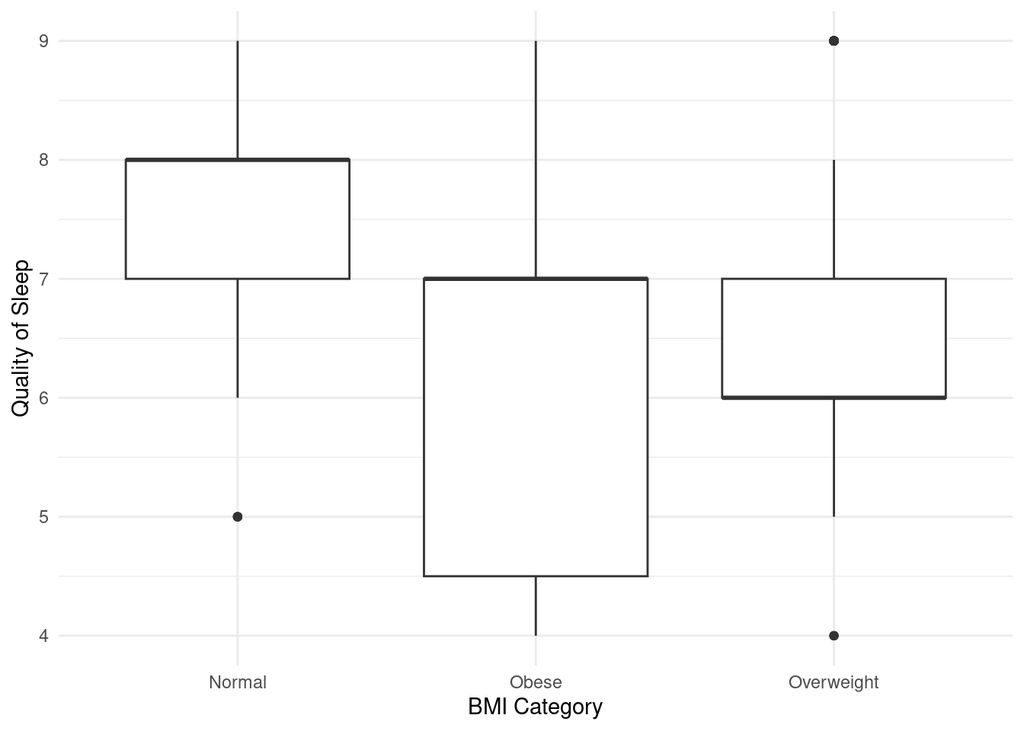

> Peoples with higher BMI are trend to have lower sleep quality

### **4. Hypothesis Testing**

##### 4.1 Relationship between BMI and Sleep disorder

- Ho: BMI category has **NO** relationship with sleep disorder
- Ha: BMI category has relationship with sleep disorder

```
##    Cell Contents
## |-------------------------|
## |                   Count |
## |          Column Percent |
## |-------------------------|
##
## ==============================================================
##                         df_h1$`Sleep Disorder`
## df_h1$`BMI Category`    Insomnia    None   Sleep Apnea   Total
## --------------------------------------------------------------
## Normal                        9     200             7     216
##                            11.7%   91.3%          9.0%
## --------------------------------------------------------------
## Obese                         4       0             6      10
##                             5.2%    0.0%          7.7%
## --------------------------------------------------------------
## Overweight                   64      19            65     148
##                            83.1%    8.7%         83.3%
## --------------------------------------------------------------
## Total                        77     219            78     374
##                            20.6%   58.6%         20.9%
## ==============================================================
##
## Statistics for All Table Factors
##
## Pearson's Chi-squared test
## ------------------------------------------------------------
## Chi^2 = 245.6653      d.f. = 4      p <2e-16
##
##         Minimum expected frequency: 2.058824
## Cells with Expected Frequency < 5: 2 of 9 (22.22222%)
```

> - Reject Ho, BMI category has relationship with sleep disorder with p-value < 0.05
> - Almost overweight peoples have Sleep disorder either insomnia or sleep apnea

##### 4.2 Relationship between BMI and Daily steps

- Ho: BMI category has **NO** relationship with daily steps
- Ha: BMI category has relationship with daily steps

```
##    Cell Contents
## |-------------------------|
## |                   Count |
## |          Column Percent |
## |-------------------------|
##
## =========================================================
##                      df_h2$`BMI Category`
## df_h2$daily_steps    Normal    Obese   Overweight   Total
## ---------------------------------------------------------
## 0-4000                   2       10            1      13
##                        0.9%   100.0%         0.7%
## ---------------------------------------------------------
## 4001-6000               67        0           83     150
##                       31.0%     0.0%        56.1%
## ---------------------------------------------------------
## 6001-8000              143        0           32     175
##                       66.2%     0.0%        21.6%
## ---------------------------------------------------------
## 8001-10000               4        0           32      36
##                        1.9%     0.0%        21.6%
## ---------------------------------------------------------
## Total                  216       10          148     374
##                       57.8%     2.7%        39.6%
## =========================================================
##
## Statistics for All Table Factors
##
## Pearson's Chi-squared test
## ------------------------------------------------------------
## Chi^2 = 372.0571      d.f. = 6      p <2e-16
##
##         Minimum expected frequency: 0.3475936
## Cells with Expected Frequency < 5: 4 of 12 (33.33333%)
```

> - Reject Ho, BMI category has relationship with daily steps with p-value < 0.05
> - Almost overweight peoples have lesser daily steps than normal weight peoples

### **5. Insights and Recommendations**

##### 5.1 Insights

Based on Data Exploration and Hypothesis Testing from 374 persons in dataset, it’s said that BMI has relationship with sleep disorder and **obese and overweight people are trend to found sleep disorder (either insomnia or sleep apnea)**

**Manager, Salesperson, Scientist, Nurse and Teacher** are top 5 occupation with highest overweight BMI category, meaning highest risk to get sleep disorder. (follow below table)

| Occupation | persons | total_normal | total_obese | total_overweight | percent_overweight |
| --- | --- | --- | --- | --- | --- |
| Manager | 1 | 0 | 0 | 1 | 100 |
| Salesperson | 32 | 0 | 0 | 32 | 100 |
| Scientist | 4 | 0 | 0 | 4 | 100 |
| Nurse | 73 | 7 | 0 | 66 | 90 |
| Teacher | 40 | 6 | 1 | 33 | 82 |
| Software Engineer | 4 | 2 | 1 | 1 | 25 |
| Accountant | 37 | 31 | 0 | 6 | 16 |
| Engineer | 63 | 60 | 0 | 3 | 5 |
| Lawyer | 47 | 43 | 2 | 2 | 4 |
| Doctor | 71 | 67 | 4 | 0 | 0 |
| Sales Representative | 2 | 0 | 2 | 0 | 0 |

##### 5.2 Recomendations

From hypothesis test in item 4.2, it’s said that BMI has relationship with Daily step and **obese and overweight about 59.5% have daily step less than 6000 (66.2% of normal BMI peoples have daily step between 6001-8000)**

> **The recommendation** is the obese and overweight peoples are encouraged to increse daily step by more walking or exercise to reduce risk to have good sleep health.